# COVID-19 across countries - report

# 1 Introduction

From Wikipedia:

> Coronavirus disease 2019 (COVID-19) is a contagious disease caused by severe acute respiratory syndrome coronavirus 2 (SARS-CoV-2). The first known case was identified in Wuhan, China in December 2019. The disease has since spread worldwide, leading to a pandemic.

This report aims to provide insight into the differences in the course of the pandemic in differences countries through simple and informative summaries and graphics.

## 1.1 Data

### 1.1.1 Countries and period

The report focuses on the following list of countries:

- **Poland**
- **France**
- **Germany**
- **Canada**
- **Brazil**
- **United States**

in the period **2020-03-01** to **2021-04-15**.

### 1.1.2 Variables

Comparison between countries is made using a set of 13 characteristics. Their list and details can be found below.

#### 1.1.2.1 List of variables used

- **confirmed**
- **deaths**
- **recovered**
- **vaccines**
- **population**
- **workplace_closing**
- **cancel_events**
- **gatherings_restrictions**
- **international_movement_restrictions**
- **stringency_index**
- **school_closing**
- **Government expenditure on education, total (% of government expenditure)**
- **Current health expenditure (% of GDP)**

#### 1.1.2.2 Details

- **confirmed**: *Cumulative number of confirmed cases.*
- **deaths**: *Cumulative number of deaths.*
- **recovered**: *Cumulative number of patients released from hospitals or reported recovered.*
- **vaccines**: *Cumulative number of doses administered. This is counted as a single dose, and may not equal the total number of people vaccinated, depending on the specific dose regime (e.g. people receive multiple doses). If a person receives one dose of the vaccine, this metric goes up by 1. If they receive a second dose, it goes up by 1 again.*
- **population**: *Total population.*
- **workplace_closing**: *0: No measures - 1: Recommend closing (or work from home) - 2: require closing for some sectors or categories of workers - 3: require closing (or work from home) all-but-essential workplaces (eg grocery stores, doctors).*
- **cancel_events**: *0: No measures - 1: Recommend cancelling - 2: Require cancelling.*
- **gatherings_restrictions**: *0: No restrictions - 1: Restrictions on very large gatherings (the limit is above 1000 people) - 2: Restrictions on gatherings between 100-1000 people - 3: Restrictions on gatherings between 10-100 people - 4: Restrictions on gatherings of less than 10 people.*
- **international_movement_restrictions**: *0: No measures - 1: Screening - 2: Quarantine arrivals from high-risk regions - 3: Ban on high-risk regions - 4: Total border closure.*
- **stringency_index**: *Stringency of governmental responses.*
- **school_closing**: *0: No measures - 1: Recommend closing - 2: Require closing (only some levels or categories, eg just high school, or just public schools - 3: Require closing all levels.*
- **Government expenditure on education, total (% of government expenditure)**
- **Current health expenditure (% of GDP)**

[More details](https://www.bsg.ox.ac.uk/sites/default/files/2020-04/BSG-WP-2020-032-v5.0.pdf) on restrictions variables.

## 1.2 Summary

Let us summarize the dataset:

Mean values of the characteristics:

### 1.2.1 Table

| id | workplace_closing_mean | cancel_events_mean | gatherings_restrictions_mean | international_movement_restrictions_mean | stringency_index_mean | school_closing_mean | Government expenditure on education, total (% of government expenditure)_mean | Current health expenditure (% of GDP)_mean | confirmed_per_100k_population_mean | deaths_per_100k_population_mean | recovered_per_100k_population_mean | vaccines_per_100k_population_mean |
| --- | --- | --- | --- | --- | --- | --- | --- | --- | --- | --- | --- | --- |
| BRA | 2.659367 | 1.946472 | 3.496350 | 1.929440 | 68.45813 | 2.883212 | 16.51236 | 9.514387 | 231.30098 | 6.311016 | 212.40467 | 702.5893 |
| CAN | 2.467153 | 1.946472 | 3.836983 | 3.875912 | 67.75584 | 2.746959 | NaN | 10.790469 | 90.29341 | 3.007390 | 85.80007 | 598.6814 |
| DEU | 2.080292 | 1.978102 | 3.734793 | 3.070560 | 65.78219 | 2.136253 | 11.04263 | 11.429951 | 109.04567 | 3.324846 | 105.72029 | 805.3587 |
| FRA | 2.109489 | 1.763990 | 4.000000 | 2.922141 | 64.43976 | 1.722628 | 9.67858 | 11.257895 | 213.45800 | 7.037976 | 19.82567 | 766.5973 |
| POL | 1.810219 | 1.372263 | 2.919708 | 3.034063 | 60.42501 | 2.301703 | 11.05911 | 6.330850 | 165.99099 | 3.899805 | 132.21694 | 745.6845 |
| USA | 2.107056 | 1.914842 | 3.693431 | 2.997567 | 66.57620 | 2.795620 | NaN | 16.885298 | 343.71538 | 7.304539 | 52.82101 | 2353.8800 |

### 1.2.2 Barplot

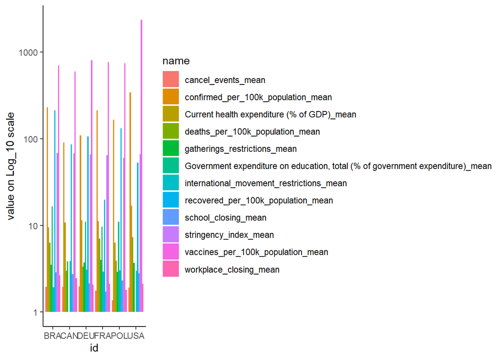

# 2 Countries’ reactions

Let’s examine how the countries reacted to pandemic in that time.

## 2.1 Course of pandemic vs. measures enforced

The figures below depict how countries reacted to the pandemic. The y-axis shows the intensity of restrictions indicated by various measures while x-axis shows, depending on the variant, number of confirmed cases or the timeline.

### 2.1.1 Stringency

Stringency measures the overall ‘severity’ of the lockdown policy.

Below we find graphs of stringency_index plotted against time and number of confirmed COVID-19 cases.

#### 2.1.1.1 …versus confirmed cases

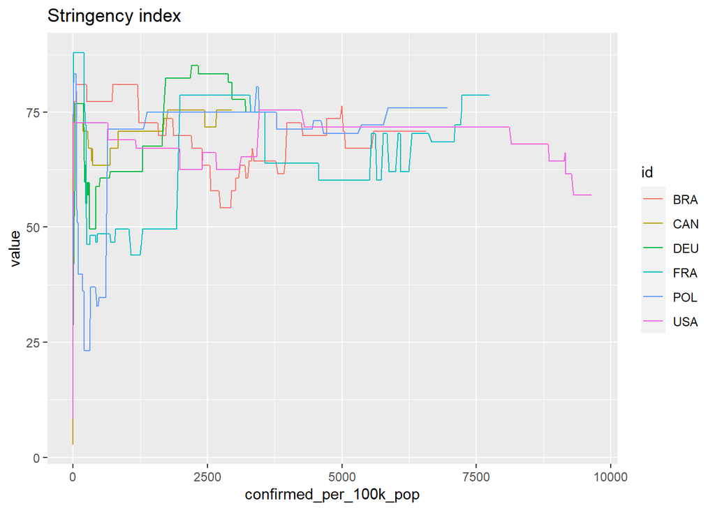

#### 2.1.1.2 …in time

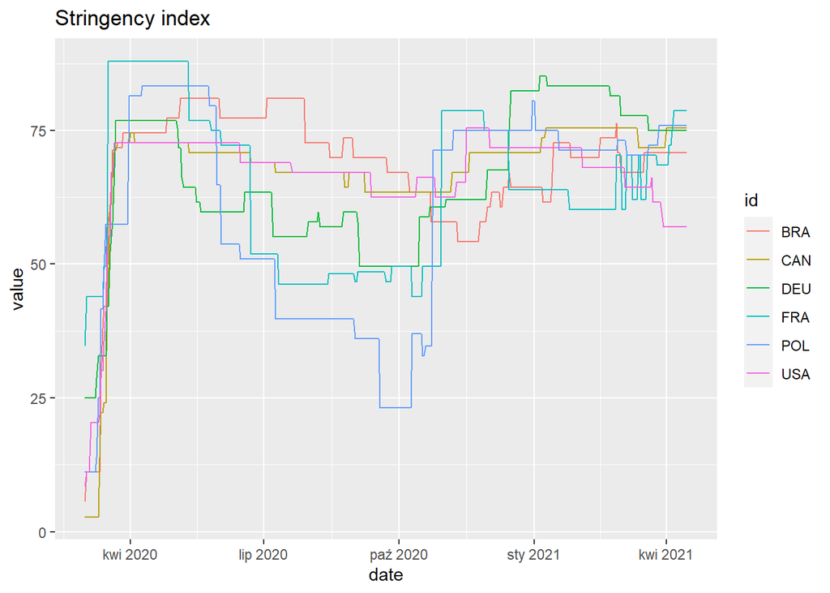

### 2.1.2 Other restrictions

Let us also analyze particular restrictive actions of the governments.

#### 2.1.2.1 …versus confirmed cases

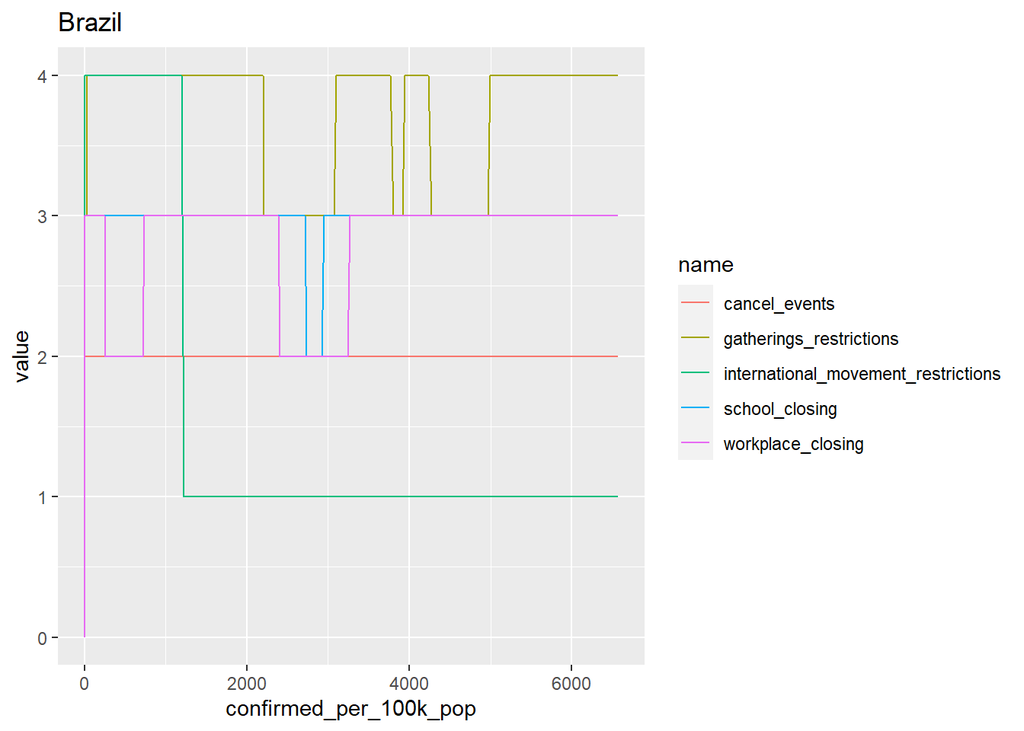

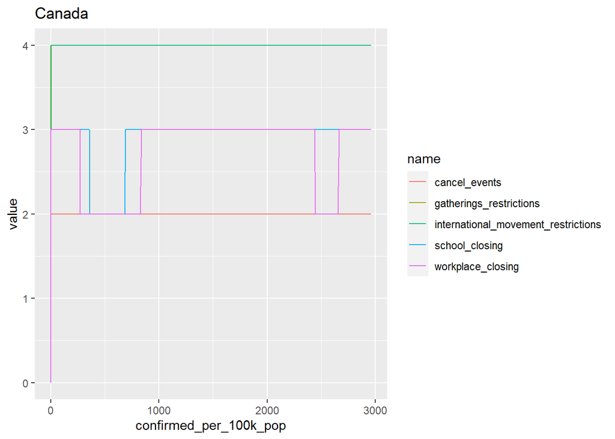

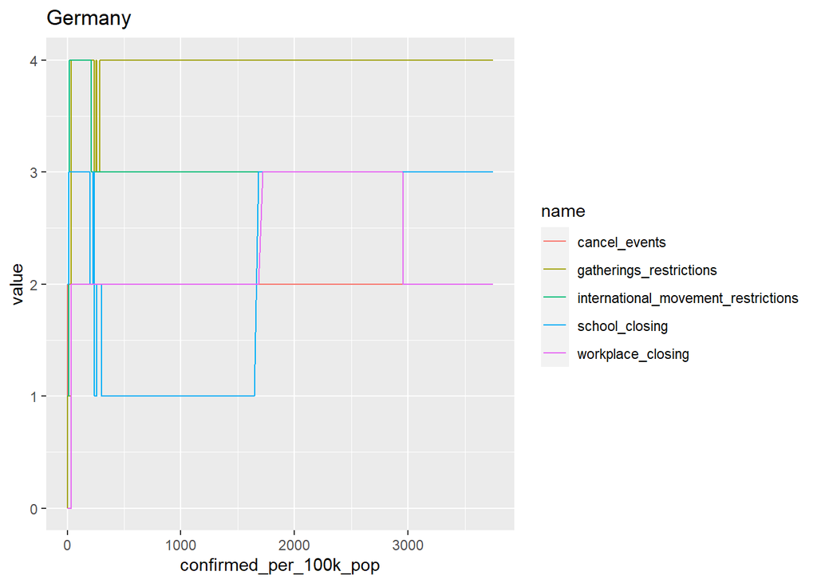

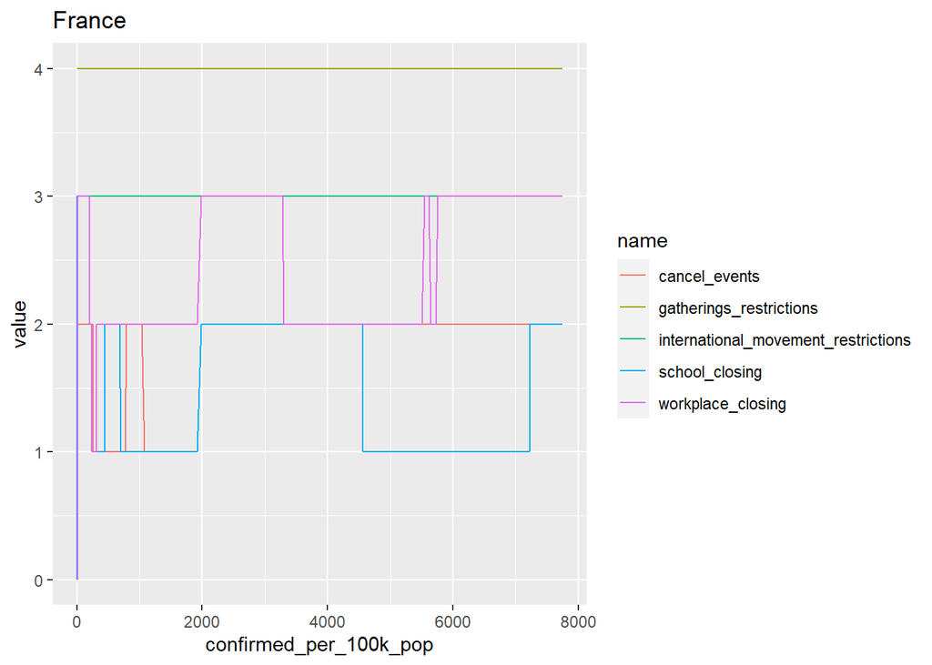

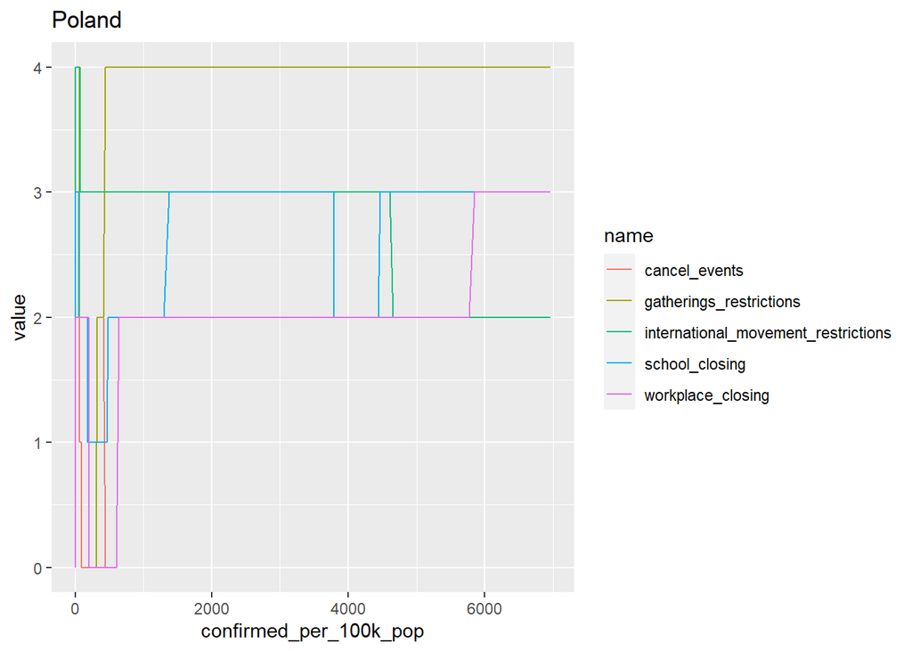

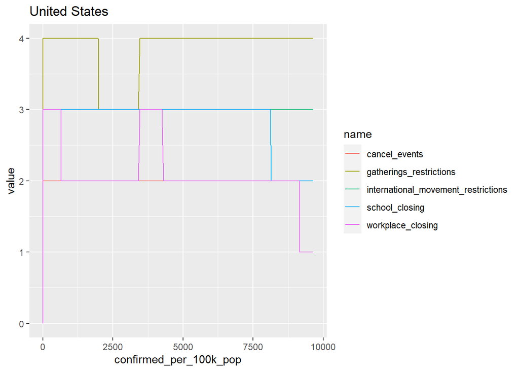

#### 2.1.2.2 …in time

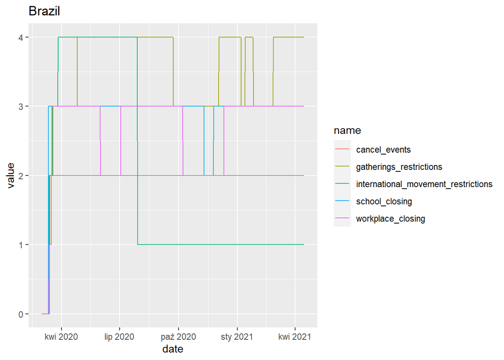

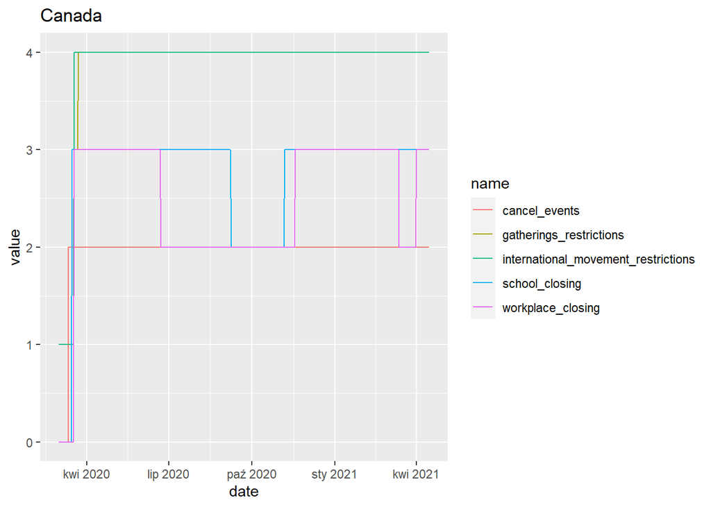

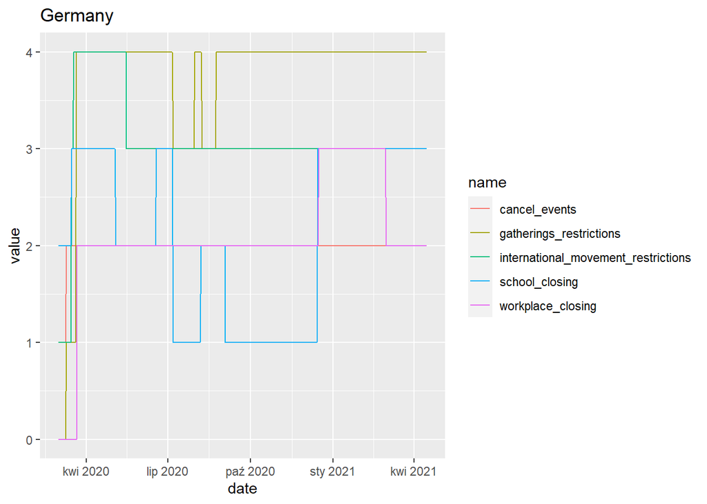

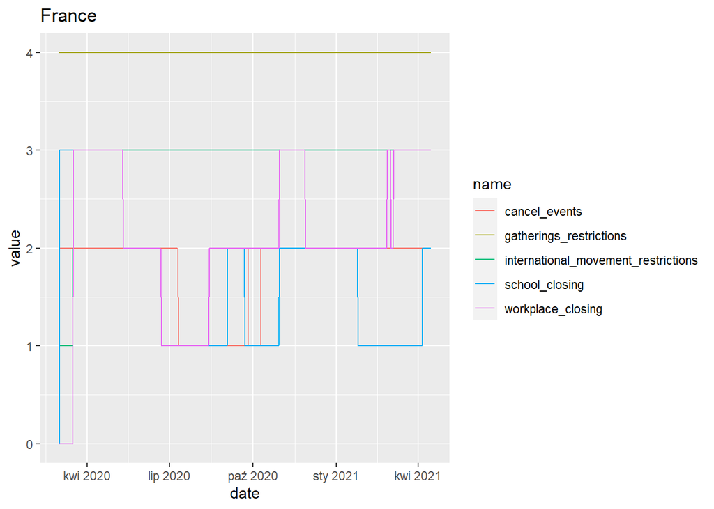

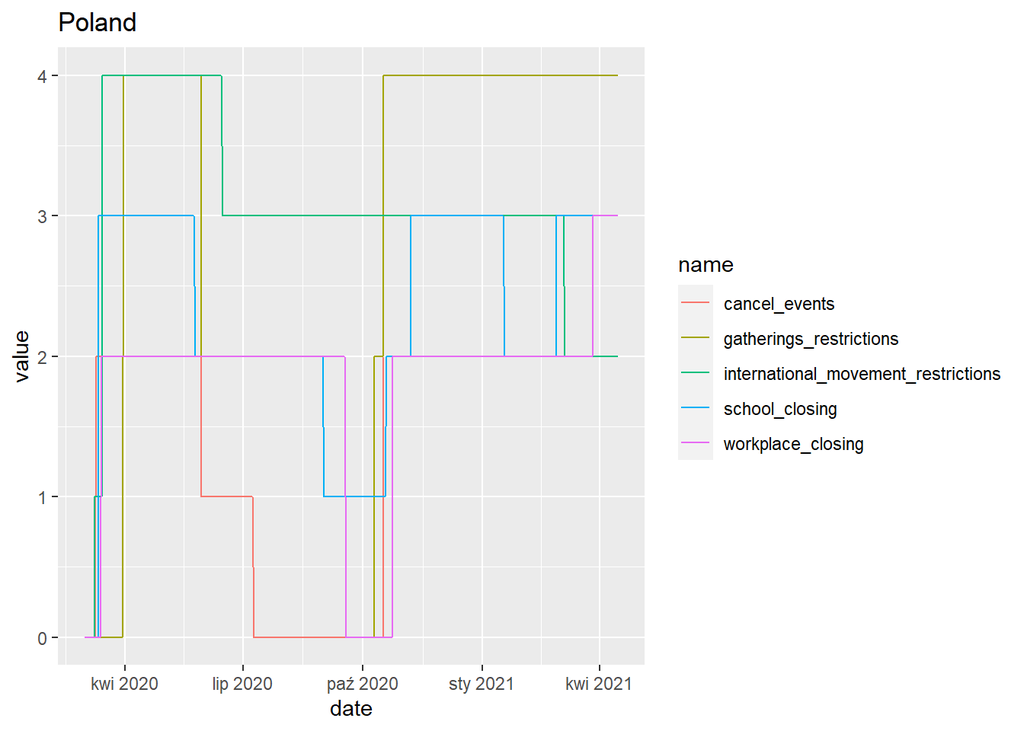

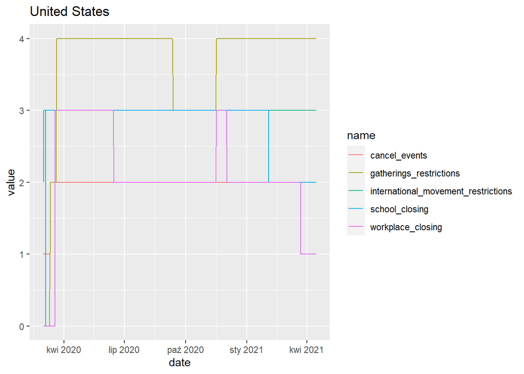

# 3 Vaccinations

The vaccination process started in **2020-12-14** and in the whole period a total number of doses administered in all selected countries amounted to **287388711**.

In the graphs below we can see the cumulative number of doses administered and number of doses administered per 100k population. It is crucial to mention that the latter value is not number of people vaccinated (only a proxy of it), as some vaccines require multiple doses for full efficiency.

## 3.1 Number of doses

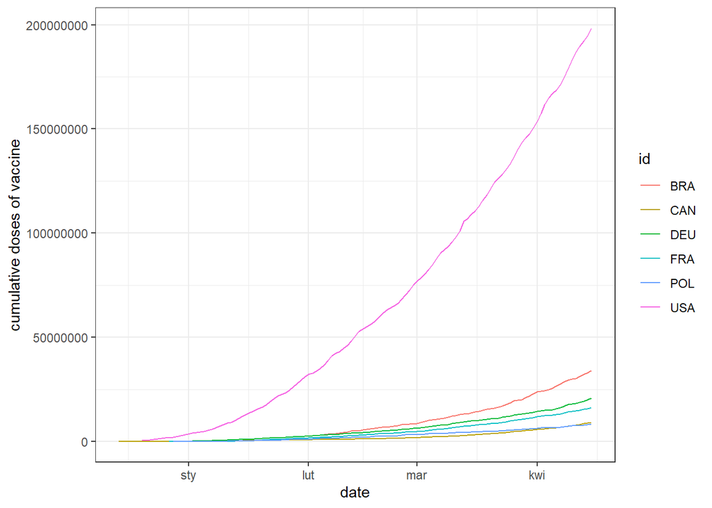

## 3.2 Number of doses per population

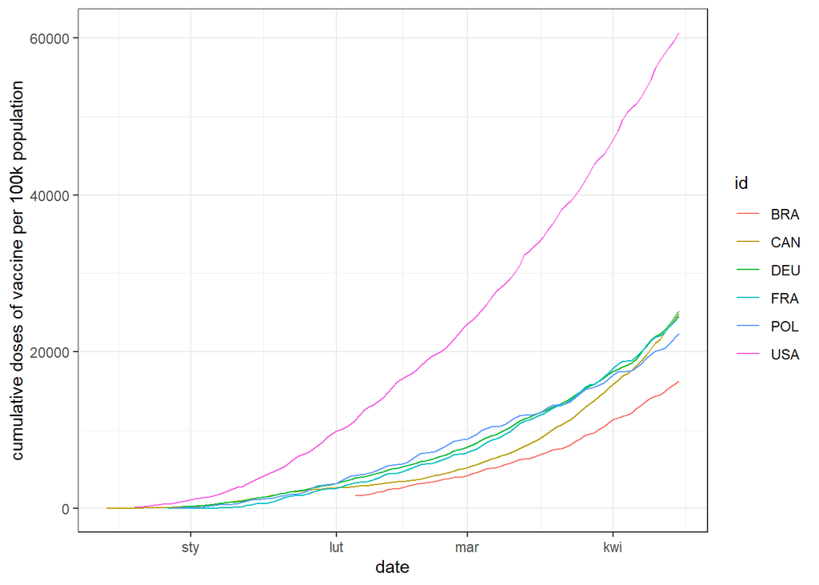